# **Introduction to Python Project : FoodHub Data Analysis - Solution Notebook**

### **Context**

FoodHub is an online food aggregator that offers online food delivery services. Customers get access to multiple restaurants through their smartphone app. The app allows for order placement, restauarant confirmation and assignment of food delivery person. The food delivery person goes to the restaurant to collect the food parcel and delivers it to the customer's location.

The FoodHub has accumulated a significant amount of order data including restaurant name, ratings given by the customer, cuisine types, cost of the order, time to prepare and deliver the food. The company seeks to gain insights from the dataset to enhance operational efficiency, customer satisfaction, and overall performance

### **Objective**

As a data scientist we need to analyze & interpret the given data set in answering the key questions, identify trends and provide data-driven recommendations to improve their services.

### **Data Dictionary**

The data contains the details for the Foodhub orders containing various details

- order_id: Unique ID of the order
- customer_id: ID of the customer who placed the order
- restaurant_name: Name of the restaurant
- cuisine_type: Types of cuisine
- cost_of_the_order: Cost of the order
- day_of_the_week: Indicated whether the order was placed on Weekday or Weekend
- rating: Rating given by the customer out of 5
- food_preparation_time: Time taken (in minutes) by the restaurant to prepare the food
- delivery_time: Time taken (in minutes) by delivery person to deliver the food package to the customer

### Let us start by importing the required libraries

```python
# Libraries for reading and manipulating data
import numpy as np
import pandas as pd

# Libraries for data visualization
import matplotlib.pyplot as plt
import seaborn as sns

# Command to display the graphs
%matplotlib inline
```

### Understanding the structure of the data

```python
from google.colab import drive
drive.mount('/content/drive')
```

```python
# To read the dataset from google drive
order_df = pd.read_csv("/content/drive/My Drive/Colab Notebooks/foodhub_order.csv")
```

```python
# To view the first 5 rows from the dataset
order_df.head(5)
```

|  | order_id | customer_id | restaurant_name | cuisine_type | cost_of_the_order | day_of_the_week | rating | food_preparation_time | delivery_time |
| --- | --- | --- | --- | --- | --- | --- | --- | --- | --- |
| 0 | 1477147 | 337525 | Hangawi | Korean | 30.75 | Weekend | Not given | 25 | 20 |
| 1 | 1477685 | 358141 | Blue Ribbon Sushi Izakaya | Japanese | 12.08 | Weekend | Not given | 25 | 23 |
| 2 | 1477070 | 66393 | Cafe Habana | Mexican | 12.23 | Weekday | 5 | 23 | 28 |
| 3 | 1477334 | 106968 | Blue Ribbon Fried Chicken | American | 29.20 | Weekend | 3 | 25 | 15 |
| 4 | 1478249 | 76942 | Dirty Bird to Go | American | 11.59 | Weekday | 4 | 25 | 24 |

#### Observations:

1. The Foodhub_order data set has been loaded successfully and been saved under variable name order_df.
2. The dataset contains details such as restaurant name, types of cuisines, cost of the order, ratings, preparation time and delivery time.
3. The first five rows reveal that some entries in the rating column are marked as "Not given".
4. Since "Not given" is a string, it makes the entire rating column an object type. For analysis, these "Not given" values should be replaced with NaN, and the column should be converted to an integer type for our data analysis.

### **Question 1:** How many rows and columns are present in the data? [0.5 mark]

```python
# To check the number of rows and columns present in the dataset
order_df.shape
```

```
(1898, 9)
```

#### Observations:

1. The dataframe contains 1898 rows and 9 columns

### **Question 2:** What are the datatypes of the different columns in the dataset? (The info() function can be used) [0.5 mark]

```python
order_df.info()
```

```
<class 'pandas.core.frame.DataFrame'>
RangeIndex: 1898 entries, 0 to 1897
Data columns (total 9 columns):
 #   Column                 Non-Null Count  Dtype
---  ------                 --------------  -----
 0   order_id               1898 non-null   int64
 1   customer_id            1898 non-null   int64
 2   restaurant_name        1898 non-null   object
 3   cuisine_type           1898 non-null   object
 4   cost_of_the_order      1898 non-null   float64
 5   day_of_the_week        1898 non-null   object
 6   rating                 1898 non-null   object
 7   food_preparation_time  1898 non-null   int64
 8   delivery_time          1898 non-null   int64
dtypes: float64(1), int64(4), object(4)
memory usage: 133.6+ KB
```

#### Observations:

1. The data set consists of 9 columns with three different data types:
- Integer (int64): Order_id, customer_id, food_preparation_time, delivery_time
- Object (object): restaurant_name, cuisine_type, day_of_the_week, rating(which should be ideally integer)
- Float (float64): cost_of_the_order
2. The rating column should be coverted to integer, after replacing all the "Not given" values with NaN
3. Remianing all other columns are stored correctly

### **Question 3:** Are there any missing values in the data? If yes, treat them using an appropriate method. [1 mark]

```python
# To check the missing values in the dataset
order_df.isnull().sum()
```

|  | 0 |
| --- | --- |
| order_id | 0 |
| customer_id | 0 |
| restaurant_name | 0 |
| cuisine_type | 0 |
| cost_of_the_order | 0 |
| day_of_the_week | 0 |
| rating | 0 |
| food_preparation_time | 0 |
| delivery_time | 0 |

**dtype:** int64

- Using the isnull().sum() function, the intial output shows that there are no missing values.
- But as I mentioned above that the rating column has few entries as "Not given" which needs to be replaced with NaN (Not a number) and then convert the datatype from object to int

```python
# To repalce the "Not given" values with Nan
order_df['rating'] = order_df['rating'].replace(['Not given'], np.nan)
```

```python
# Changing datatype of rating from object to float (Since the column contains NaN values, it can't be converted into int, so will initally convert the datatype to float)
order_df['rating'] = order_df['rating'].astype(float)
```

```python
# Now checking the missing values after replcing with NaN
order_df.isnull().sum()
```

|  | 0 |
| --- | --- |
| order_id | 0 |
| customer_id | 0 |
| restaurant_name | 0 |
| cuisine_type | 0 |
| cost_of_the_order | 0 |
| day_of_the_week | 0 |
| rating | 736 |
| food_preparation_time | 0 |
| delivery_time | 0 |

**dtype:** int64

```python
# The code identifies restaurants with missing ratings and counts how many missing values each restaurant has.
order_df.loc[order_df['rating'].isnull()==True, 'restaurant_name'].value_counts()
```

| restaurant_name | count |
| --- | --- |
| Shake Shack | 86 |
| The Meatball Shop | 48 |
| Blue Ribbon Sushi | 46 |
| Blue Ribbon Fried Chicken | 32 |
| Parm | 29 |
| ... | ... |
| Hiroko's Place | 1 |
| Blue Ribbon Brooklyn | 1 |
| Zero Otto Nove | 1 |
| DuMont Burger | 1 |
| Amy Ruth's | 1 |

134 rows × 1 columns

**dtype:** int64

- The output shows that 134 restaurants have missing rating values, with Shake Shack having the highest count at 86. Let's fill the missing values using the median rating grouped by restaurant name.

```python
# Fill the NaN values in the rating column, we will group the data by restaurant_name and replace missing values with the median rating of each restaurant.
order_df['rating'] = order_df['rating'].fillna(value = order_df.groupby(['restaurant_name'])['rating'].transform('median'))
```

```python
# Check for missing values after filling them with the median ratings.
order_df.isnull().sum()
```

|  | 0 |
| --- | --- |
| order_id | 0 |
| customer_id | 0 |
| restaurant_name | 0 |
| cuisine_type | 0 |
| cost_of_the_order | 0 |
| day_of_the_week | 0 |
| rating | 30 |
| food_preparation_time | 0 |
| delivery_time | 0 |

**dtype:** int64

- We can see that 30 rows in the rating column still have missing values. We will investigate further by grouping them based on restaurant names.

```python
# Again check restaurants with missing ratings and counts how many missing values each restaurant has.
order_df.loc[order_df['rating'].isnull()==True, 'restaurant_name'].value_counts()
```

| restaurant_name | count |
| --- | --- |
| Room Service | 3 |
| Friend of a Farmer | 3 |
| Tarallucci e Vino Restaurant | 2 |
| Hangawi | 2 |
| Bistango | 2 |
| Aurora | 2 |
| Big Wong Restaurant _¤¾Ñ¼ | 1 |
| Posto | 1 |
| Gaia Italian Cafe | 1 |
| Spice Thai | 1 |
| Rohm Thai | 1 |
| Alidoro | 1 |
| La Follia | 1 |
| Crema Restaurante | 1 |
| Market Table | 1 |
| Lamarca Pasta | 1 |
| Paul & Jimmy's | 1 |
| Coppola's East | 1 |
| Emporio | 1 |
| Wa Jeal | 1 |
| Le Zie 2000 Trattoria | 1 |
| Hiroko's Place | 1 |

**dtype:** int64

- The above restaurants still have missing ratings because all of their ratings were missing in the first place, so there was no existing data to calculate a median.
- Since only 30 rows are missing values in the rating column, I will now fill them with the global median value.

```python
# Fill in the remining NaN with global median
order_df['rating'] = order_df['rating'].fillna(order_df['rating'].median())
```

```python
# Check restaurants if there is any missing ratings and counts how many missing values each restaurant has.
order_df.loc[order_df['rating'].isnull()==True, 'restaurant_name'].value_counts()
```

|  | count |
| --- | --- |
| restaurant_name |  |

**dtype:** int64

- The above output confirms that there are no missing values and all the missing values are treated.
- Since all the NaN values are replaced I will change the datatype of rating to int and confirm that with info() function.

```python
# Changing datatype of rating from float to int
order_df['rating'] = order_df['rating'].astype(int)
```

```python
order_df.info()
```

```
<class 'pandas.core.frame.DataFrame'>
RangeIndex: 1898 entries, 0 to 1897
Data columns (total 9 columns):
 #   Column                 Non-Null Count  Dtype
---  ------                 --------------  -----
 0   order_id               1898 non-null   int64
 1   customer_id            1898 non-null   int64
 2   restaurant_name        1898 non-null   object
 3   cuisine_type           1898 non-null   object
 4   cost_of_the_order      1898 non-null   float64
 5   day_of_the_week        1898 non-null   object
 6   rating                 1898 non-null   int64
 7   food_preparation_time  1898 non-null   int64
 8   delivery_time          1898 non-null   int64
dtypes: float64(1), int64(5), object(3)
memory usage: 133.6+ KB
```

- The above output confirms that rating column is converted to int and has no missing values

### **Question 4:** Check the statistical summary of the data. What is the minimum, average, and maximum time it takes for food to be prepared once an order is placed? [2 marks]

```python
# Restrict the float value to 3 decimal places
pd.set_option('display.float_format', lambda x: '%.3f' % x)

# View the statistical summary of the data
order_df.describe().T
```

|  | count | mean | std | min | 25% | 50% | 75% | max |
| --- | --- | --- | --- | --- | --- | --- | --- | --- |
| order_id | 1898.000 | 1477495.500 | 548.050 | 1476547.000 | 1477021.250 | 1477495.500 | 1477969.750 | 1478444.000 |
| customer_id | 1898.000 | 171168.478 | 113698.140 | 1311.000 | 77787.750 | 128600.000 | 270525.000 | 405334.000 |
| cost_of_the_order | 1898.000 | 16.499 | 7.484 | 4.470 | 12.080 | 14.140 | 22.297 | 35.410 |
| rating | 1898.000 | 4.344 | 0.664 | 3.000 | 4.000 | 4.000 | 5.000 | 5.000 |
| food_preparation_time | 1898.000 | 27.372 | 4.632 | 20.000 | 23.000 | 27.000 | 31.000 | 35.000 |
| delivery_time | 1898.000 | 24.162 | 4.973 | 15.000 | 20.000 | 25.000 | 28.000 | 33.000 |

#### Observations:

1. By using the describe() fucntion we can see the whole statistical summary of the data set.
2. The output shows the count, mean, standard deviation, min, 25% (Q1), 50% (Median or Q2), 75% (Q3) and max for all the numerical columns in the dataset.
3. The minimum, average, and maximum time it takes for food to be prepared once order is placed:
- **Minimum** food preparation time: **20.00 minutes**
- **Average** food preparation time: **27.37 minutes**
- **Maximum** food preparation time: **35.00 minutes**

### **Question 5:** How many orders are not rated? [1 mark]

```python
order_df['rating'].isnull().sum()
```

```
np.int64(0)
```

- There were missing values in the rating column, but they were addressed in question number 3.

#### **Screenshot from question 3**

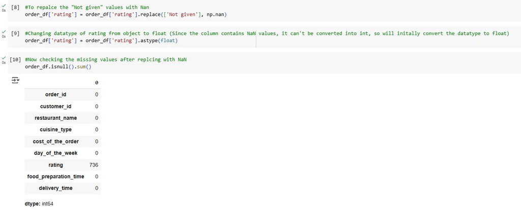

#### Observations:

1. In Question 3, I identified that the rating column contained 736 rows with the value "Not given", which were then converted to NaN.
2. To handle missing values, I filled NaN ratings with the median rating grouped by restaurant name.
3. After this treatment, there are no orders with missing ratings in the dataset.

### **Exploratory Data Analysis (EDA)**

### **Question 6:** Explore all the variables and provide observations on their distributions. (Generally, histograms, boxplots, countplots, etc. are used for univariate exploration.) [9 marks]

### Overview of the data

```python
order_df.head(3)
```

|  | order_id | customer_id | restaurant_name | cuisine_type | cost_of_the_order | day_of_the_week | rating | food_preparation_time | delivery_time |
| --- | --- | --- | --- | --- | --- | --- | --- | --- | --- |
| 0 | 1477147 | 337525 | Hangawi | Korean | 30.750 | Weekend | 4 | 25 | 20 |
| 1 | 1477685 | 358141 | Blue Ribbon Sushi Izakaya | Japanese | 12.080 | Weekend | 5 | 25 | 23 |
| 2 | 1477070 | 66393 | Cafe Habana | Mexican | 12.230 | Weekday | 5 | 23 | 28 |

### Order ID Column

```python
# To check if any duplicates in the dataset
order_df.duplicated().sum()
```

```
np.int64(0)
```

```python
# Unique number of orders in the dataset
order_df['order_id'].nunique()
```

```
1898
```

#### Observations:

1. The dataset contains 1,898 unique orders, confirming that all order IDs are unique, with no duplicate entries.

### Customer ID Column

```python
# Unique number of customer id's in the dataset
order_df['customer_id'].nunique()
```

```
1200
```

```python
# Retrieves the top 5 customers who have placed the highest number of orders
order_df['customer_id'].value_counts(ascending=False).head(5)
```

| customer_id | count |
| --- | --- |
| 52832 | 13 |
| 47440 | 10 |
| 83287 | 9 |
| 250494 | 8 |
| 259341 | 7 |

**dtype:** int64

#### Observations:

1. There are 1,200 unique customers, meaning that some customers have placed multiple orders.
2. The output shows the top 5 customers who placed highest number of orders.
3. Customer ID 52832 has placed 13 orders, making them the most frequent customer in the dataset.

### Restaurant Name Column

```python
# Count the number of unique restaurant in the dataset
order_df['restaurant_name'].nunique()
```

```
178
```

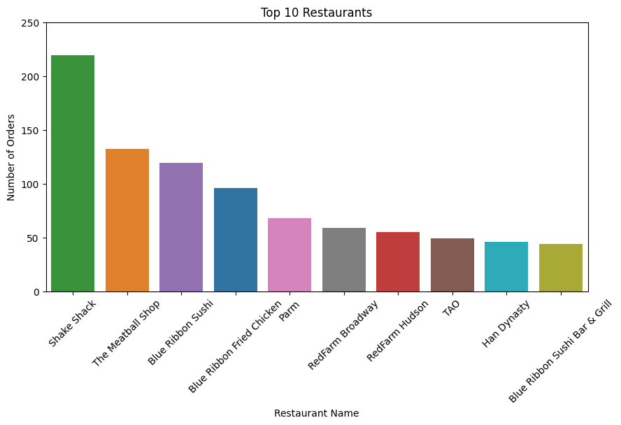

```python
# top 10 restaurants with highest number of orders
top_10_restaurant = order_df['restaurant_name'].value_counts().head(10).index

# Filtered dataset containing only top 10 restaurants
filtered_df_barplot = order_df[order_df['restaurant_name'].isin(top_10_restaurant)]

# Bar plot
plt.figure(figsize = (10,5))
sns.countplot(data = filtered_df_barplot, x='restaurant_name', order = top_10_restaurant, hue = 'restaurant_name');

# Plot customization
plt.xticks(rotation = 45)
plt.title('Top 10 Restaurants')
plt.ylim(0,250)
plt.xlabel('Restaurant Name')
plt.ylabel('Number of Orders')

# Show the plot
plt.show()
```

#### Observations:

1. There are 178 unique restaurants in the dataset.
2. The bar graph displays the top 10 restaurants based on the number of orders.
3. Shake Shack has received the highest number of orders, making it the most popular restaurant in the dataset, followed by The Meatball Shop in the second place and Blue Ribbon Sushi in the third place.

### Cuisine Type Column

```python
# Unique cuisines names
order_df['cuisine_type'].unique()
```

```
array(['Korean', 'Japanese', 'Mexican', 'American', 'Indian', 'Italian',
       'Mediterranean', 'Chinese', 'Middle Eastern', 'Thai', 'Southern',
       'French', 'Spanish', 'Vietnamese'], dtype=object)
```

```python
# Number of unique cuisines in the dataset
order_df['cuisine_type'].nunique()
```

```
14
```

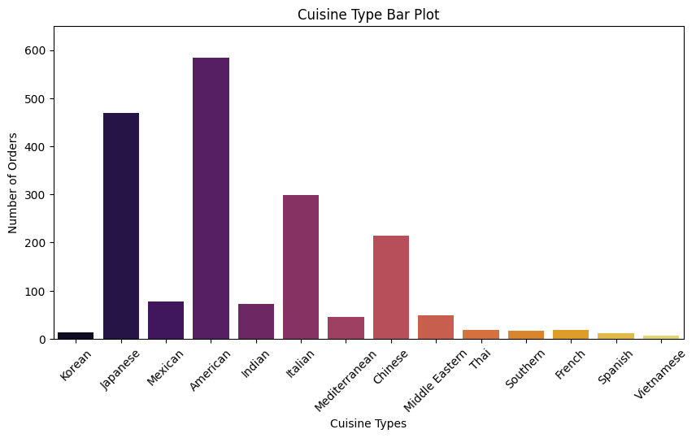

```python
# Bar plot
plt.figure(figsize = (10,5))
sns.countplot(data=order_df, x='cuisine_type', hue='cuisine_type', palette='inferno', legend=False)

# Plot customization
plt.xticks(rotation = 45)
plt.title('Cuisine Type Bar Plot')
plt.ylim(0,650)
plt.xlabel('Cuisine Types')
plt.ylabel('Number of Orders')

# Show the plot
plt.show()
```

#### Observations:

1. There are 14 unique cuisines in the dataset.
2. American, Japanese and Italian are the most popular cuisines with highest number of orders respectively.
3. Vietnamese, Spanish and Korean are the least popluar cuisines based on the dataset

### Cost of the Order Column

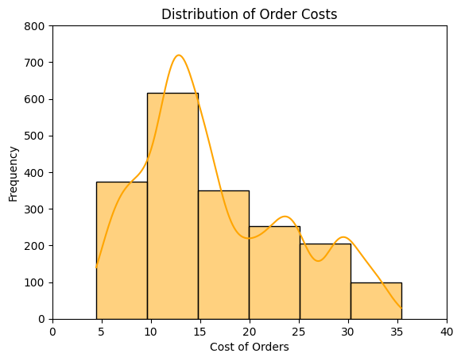

```python
# Histogram for cost of the order
sns.histplot(data = order_df, x = 'cost_of_the_order', binwidth = 5, kde = True, color = 'orange');

# Plot customization
plt.title('Distribution of Order Costs')
plt.xlim(0,40)
plt.ylim(0,800)
plt.xlabel('Cost of Orders')
plt.ylabel('Frequency')

# Show the plot
plt.show()
```

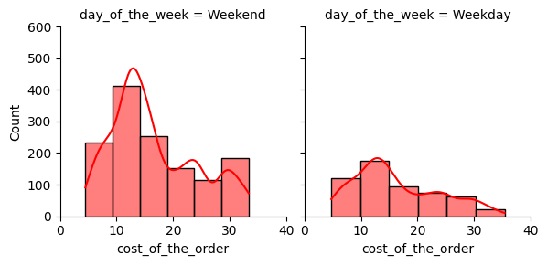

```python
# To make subplots of the cost of order based on day of the week
g = sns.FacetGrid(order_df, col = 'day_of_the_week')
g.map(sns.histplot, 'cost_of_the_order', binwidth=5, kde = True, color = 'red')

# Plot customization
plt.xlim(0,40)
plt.ylim(0,600)

# Show the plot
plt.show()
```

#### Observations:

1. Histogram Plot
   - Histogram plot of distribution of order cost shows that order range between 10$ to 15$ has highest number of orders.
   - The distribution appears right-skewed, meaning fewer high-cost orders are placed compared to lower-cost ones.
   - Orders above 30$ are significantly less frequent meaning expensive meals are not that popular
2. Order Cost by Day of the Week
   - The weekend has highest number of orders, especially in the range 10$ to 15$
   - The weekday orders are significantly lower in frequency compared to weekends, suggesting less demand during workdays.
   - The distribution is right-skewed for both weekdays and weekends
   - The most common order range ($10–$15) remains consistent across both weekdays and weekends.

### Day of the Week Column

```python
order_df['day_of_the_week'].value_counts()
```

| day_of_the_week | count |
| --- | --- |
| Weekend | 1351 |
| Weekday | 547 |

**dtype:** int64

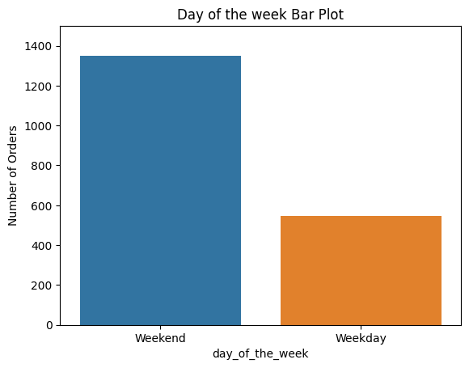

```python
# Bar plot
sns.countplot(data=order_df, x='day_of_the_week', hue='day_of_the_week')

# Plot customization
plt.title('Day of the week Bar Plot')
plt.ylim(0,1500)
plt.ylabel('Number of Orders')

# Show the plot
plt.show()
```

#### Observations:

1. The number of orders is significantly higher on weekends compared to weekdays.
2. The demand is very less during the weekday compared to weekend.
3. Higher weekend demand means comapany need more delivery personals to meet the surge.

### Rating Column

```python
# frequency of each unique rating value in the dataset.
order_df['rating'].value_counts()
```

| rating | count |
| --- | --- |
| 5 | 856 |
| 4 | 838 |
| 3 | 204 |

**dtype:** int64

```python
# Statistical summary
order_df['rating'].describe()
```

|  | rating |
| --- | --- |
| count | 1898.000 |
| mean | 4.344 |
| std | 0.664 |
| min | 3.000 |
| 25% | 4.000 |
| 50% | 4.000 |
| 75% | 5.000 |
| max | 5.000 |

**dtype:** float64

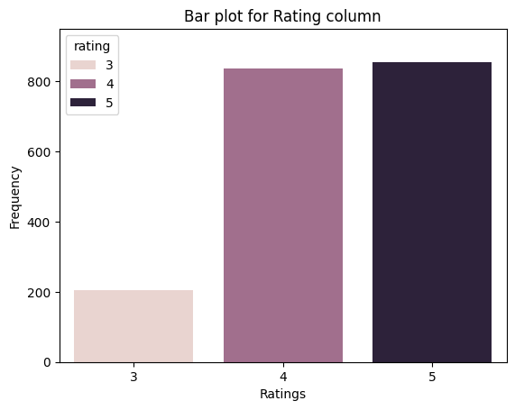

```python
# Bar plot
sns.countplot(data = order_df, x = 'rating', hue= 'rating')

# Plot customization
plt.title('Bar plot for Rating column')
plt.ylim(0,950)
plt.xlabel('Ratings')
plt.ylabel('Frequency')

# Show the plot
plt.show()
```

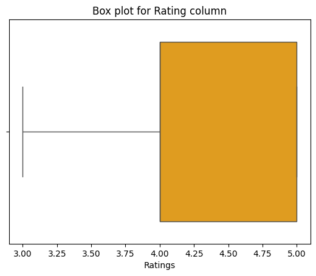

```python
# Box plot
sns.boxplot(data = order_df, x = 'rating', color = 'orange')

# Plot customization
plt.title('Box plot for Rating column')
plt.xlabel('Ratings')

# Show the plot
plt.show()
```

#### Observations:

1. Statistical Summary:
   - The average rating is 4.34, indicating that most customers are satisfied with their orders.
   - The minimum rating is 3, which implies customer rarely give low ratings.
   - The dataset reflects strongly positive customer feedback, with very few negative ratings. This suggests high service quality and customer satisfaction.
2. Bar Plot observation:
   - Ratings of 4 and 5 dominate the dataset, indicating strong customer satisfaction.
   - The counts for 4 and 5 ratings are nearly equal, showing that customers frequently give high ratings.
   - Only a small portion of ratings are 3, which suggests that negative feedback is minimal.
3. Box plot observation:
   - There are no outliers in the dataset
   - As confirmed in the bar plot, majority of the ratings fall between 4 and 5

### Food Preparation Time Column

```python
# Statistical summary
order_df['food_preparation_time'].describe()
```

|  | food_preparation_time |
| --- | --- |
| count | 1898.000 |
| mean | 27.372 |
| std | 4.632 |
| min | 20.000 |
| 25% | 23.000 |
| 50% | 27.000 |
| 75% | 31.000 |
| max | 35.000 |

**dtype:** float64

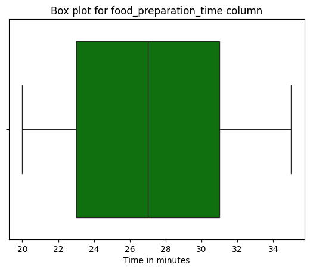

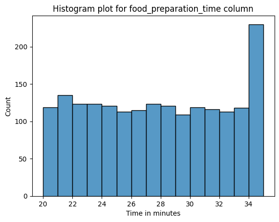

```python
# Box plot
sns.boxplot(data = order_df, x = 'food_preparation_time', color = 'green')
plt.title('Box plot for food_preparation_time column')
plt.xlabel('Time in minutes')
plt.show()

# Histogram plot
sns.histplot(data = order_df, x = 'food_preparation_time', bins = 15)
plt.title('Histogram plot for food_preparation_time column')
plt.xlabel('Time in minutes')
plt.show()
```

#### Observations:

1. The box plot indicates that majority of the orders food preparation time is in between 23 miniutes (Q1) and 31 minutes (Q3).
2. Since the mean (27.37 min) and median (27 min) are almost equal, the preparation time appears evenly distributed.
3. The box plot does not show any outliers, meaning all preparation times fall within a reasonable range.
4. The minimum time taken to prepare the food is 20 minutes and maximum is 35 minutes.
5. The histogram plot shows the distribution appears relatively even across the range.
6. No major skewness as per histogram plot.

### Delivery Time Column

```python
# Statistical summary
order_df['delivery_time'].describe()
```

|  | delivery_time |
| --- | --- |
| count | 1898.000 |
| mean | 24.162 |
| std | 4.973 |
| min | 15.000 |
| 25% | 20.000 |
| 50% | 25.000 |
| 75% | 28.000 |
| max | 33.000 |

**dtype:** float64

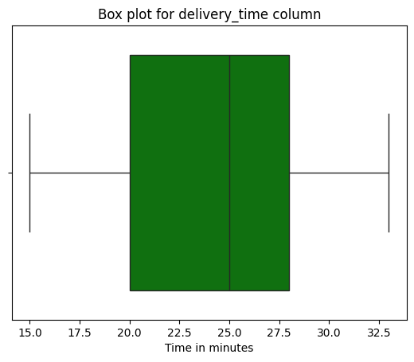

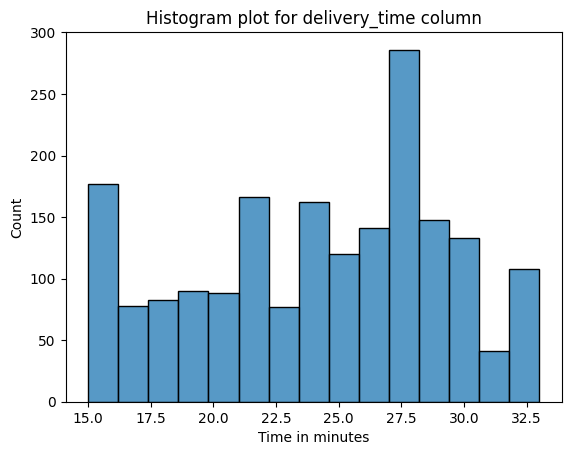

```python
# Box plot
sns.boxplot(data = order_df, x = 'delivery_time', color = 'green')
plt.title('Box plot for delivery_time column')
plt.xlabel('Time in minutes')
plt.show()

# Histogram plot
sns.histplot(data = order_df, x = 'delivery_time', bins = 15)
plt.title('Histogram plot for delivery_time column')
plt.xlabel('Time in minutes')
plt.show()
```

#### Observations:

1. From the statistical summary, the average food delivery time is 24.16 minutes.
2. The fastest delivery took 15 minutes, while the longest took 33 minutes.
3. The majority of orders were delivered in 20 to 28 minutes, as shown in the box plot.
4. The box plot does not indicate any outliers, meaning all delivery times fall within a reasonable range.
5. The histogram confirms that a significant number of orders took 26 to 28 minutes to be delivered.

### **Question 7**: Which are the top 5 restaurants in terms of the number of orders received? [1 mark]

```python
# View the top5 restaurants with most number of orders
top_5_restaurants = order_df['restaurant_name'].value_counts().head(5)
top_5_restaurants
```

| restaurant_name | count |
| --- | --- |
| Shake Shack | 219 |
| The Meatball Shop | 132 |
| Blue Ribbon Sushi | 119 |
| Blue Ribbon Fried Chicken | 96 |
| Parm | 68 |

**dtype:** int64

#### Observations:

1. Shake Shack received the highest number of orders with 219, making it the most popular restaurant.
2. The Meatball Shop follows with 132 orders.
3. Blue Ribbon Sushi, Blue Ribbon Fried Chicken, and Parm received 119, 96, and 68 orders, respectively.
4. This ranking highlights the most in-demand restaurants as per the dataset.

### **Question 8**: Which is the most popular cuisine on weekends? [1 mark]

```python
# Filter the dataset for only weekend orders and save it a new variable called order_df_filtered_by_weekend
order_df_filtered_by_weekend = order_df.loc[order_df['day_of_the_week'] == 'Weekend']
order_df_filtered_by_weekend
```

|  | order_id | customer_id | restaurant_name | cuisine_type | cost_of_the_order | day_of_the_week | rating | food_preparation_time | delivery_time |
| --- | --- | --- | --- | --- | --- | --- | --- | --- | --- |
| 0 | 1477147 | 337525 | Hangawi | Korean | 30.750 | Weekend | 4 | 25 | 20 |
| 1 | 1477685 | 358141 | Blue Ribbon Sushi Izakaya | Japanese | 12.080 | Weekend | 5 | 25 | 23 |
| 3 | 1477334 | 106968 | Blue Ribbon Fried Chicken | American | 29.200 | Weekend | 3 | 25 | 15 |
| 6 | 1477894 | 157711 | The Meatball Shop | Italian | 6.070 | Weekend | 5 | 28 | 21 |
| 11 | 1478437 | 221206 | Empanada Mama (closed) | Mexican | 8.100 | Weekend | 5 | 23 | 22 |
| ... | ... | ... | ... | ... | ... | ... | ... | ... | ... |
| 1891 | 1476981 | 138586 | Shake Shack | American | 5.820 | Weekend | 4 | 22 | 28 |
| 1892 | 1477473 | 97838 | Han Dynasty | Chinese | 29.150 | Weekend | 5 | 29 | 21 |
| 1893 | 1476701 | 292602 | Chipotle Mexican Grill $1.99 Delivery | Mexican | 22.310 | Weekend | 5 | 31 | 17 |
| 1894 | 1477421 | 397537 | The Smile | American | 12.180 | Weekend | 5 | 31 | 19 |
| 1897 | 1478056 | 120353 | Blue Ribbon Sushi | Japanese | 19.450 | Weekend | 4 | 28 | 24 |

1351 rows × 9 columns

```python
# Count the occurrences of each cuisine type during weekend
order_df_filtered_by_weekend['cuisine_type'].value_counts()
```

| cuisine_type | count |
| --- | --- |
| American | 415 |
| Japanese | 335 |
| Italian | 207 |
| Chinese | 163 |
| Mexican | 53 |
| Indian | 49 |
| Middle Eastern | 32 |
| Mediterranean | 32 |
| Thai | 15 |
| French | 13 |
| Korean | 11 |
| Southern | 11 |
| Spanish | 11 |
| Vietnamese | 4 |

**dtype:** int64

#### Observations:

1. At first, the dataset was filtered by only showing the orders received during the weekend.
2. The filtered dataset was used to count the occurrences of each cuisine type.
3. The output confirms that American cuisine is the most popular choice on weekends, indicating a higher preference for this type of food during that period.

### **Question 9**: What percentage of the orders cost more than 20 dollars? [2 marks]

```python
# Get the number of orders where the cost of the order is greater than 20$
orders_above_20 = order_df.loc[order_df['cost_of_the_order'] > 20].shape[0]
orders_above_20
```

```
555
```

```python
# Get the total number of orders
total_orders = order_df.shape[0]
total_orders
```

```
1898
```

```python
# Calculate the percentage of orders costing more than 20$
percentage_above_20 = (orders_above_20 / total_orders) * 100
print(f"{percentage_above_20:.2f}% of the total order costs more than 20$")
```

```
29.24% of the total order costs more than 20$
```

#### Observations:

1. 29.24 % of the orders cost more than 20$, indicating only a significant portion of customers tend to place high price orders.
2. The remaining 70.76% of orders cost 20$ or less, indicating that most customers opt for low price orders.

### **Question 10**: What is the mean order delivery time? [1 mark]

```python
mean_delivery_time = order_df['delivery_time'].mean()
print(f"The mean order delivery time is {mean_delivery_time:.2f} minutes")
```

```
The mean order delivery time is 24.16 minutes
```

#### Observations:

1. The average time taken for an order to be delivered is 24.16 minutes.

### **Question 11:** The company has decided to give 20% discount vouchers to the top 3 most frequent customers. Find the IDs of these customers and the number of orders they placed. [1 mark]

```python
order_df['customer_id'].value_counts().head(3)
```

| customer_id | count |
| --- | --- |
| 52832 | 13 |
| 47440 | 10 |
| 83287 | 9 |

**dtype:** int64

#### Observations:

1. The top 3 most frequent customers have been identified based on the number of orders placed.
2. Customer ID 52832 has placed the highest number of orders, with 13 orders.
3. Customer ID 47440 follows with 10 orders, and Customer ID 83287 has 9 orders.
4. These 3 top customers will be eligible to recieve the 20% discount vouchers.

### **Question 12**: Perform a multivariate analysis to explore relationships between the important variables in the dataset. (It is a good idea to explore relations between numerical variables as well as relations between numerical and categorical variables) [10 marks]

```python
order_df.head(2)
```

|  | order_id | customer_id | restaurant_name | cuisine_type | cost_of_the_order | day_of_the_week | rating | food_preparation_time | delivery_time |
| --- | --- | --- | --- | --- | --- | --- | --- | --- | --- |
| 0 | 1477147 | 337525 | Hangawi | Korean | 30.750 | Weekend | 4 | 25 | 20 |
| 1 | 1477685 | 358141 | Blue Ribbon Sushi Izakaya | Japanese | 12.080 | Weekend | 5 | 25 | 23 |

### 1. Relationship between Food Preparation Time and Cost of the order

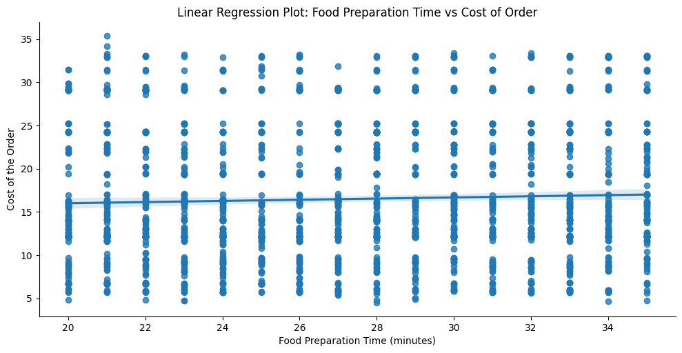

```python
# Creating lmplot for food preparation time and cost of the order
sns.lmplot(data = order_df, x = 'food_preparation_time', y='cost_of_the_order', height = 5, aspect = 2)

# Plot customization
plt.title("Linear Regression Plot: Food Preparation Time vs Cost of Order")
plt.xlabel("Food Preparation Time (minutes)")
plt.ylabel("Cost of the Order")

# Show the plot
plt.show()
```

#### Observations:

1. The graph indicates a weak correlation between food preparation time and cost of the order.
2. Even when the food preparation time is constant, order costs vary from low to high.
3. The regression line suggests a very slight upward trend, meaning as cost of the order increases, the food preparation time tends to increase slightly. However, the trend is not strong enough to suggest a direct relationship.

### 2. Relationship between Rating and Cost of the order

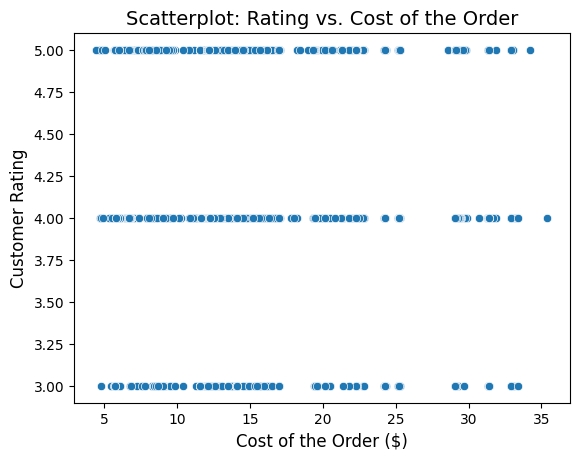

```python
# Creating Scatterplot for Rating and cost of the order
sns.scatterplot(data = order_df, y='rating', x = 'cost_of_the_order');

# Plot customization
plt.title("Scatterplot: Rating vs. Cost of the Order", fontsize=14)
plt.xlabel("Cost of the Order ($)", fontsize=12)
plt.ylabel("Customer Rating", fontsize=12)

# Show the plot
plt.show()
```

#### Observation:

1. The scatter plot suggests no strong correlation between rating and cost of the order.
2. The order cost appears randomly distributed across different rating values (3, 4, and 5).
3. Customers gave ratings in the range of 3 to 5, regardless of the cost of the order.

### 3. Relationship Between Rating, Delivery Time, and Food Preparation Time

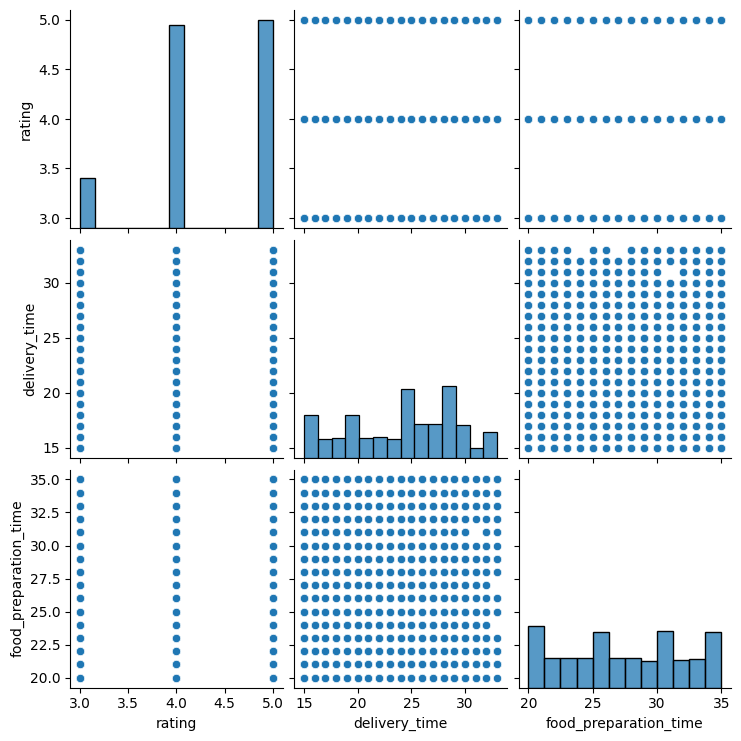

```python
# Creating Pair plot for Rating, Delivery Time, and Food Preparation Time
sns.pairplot(order_df, vars=['rating', 'delivery_time', 'food_preparation_time'])
plt.show()

# Show the plot
plt.show()
```

#### Observations:

1. No strong correlation exists between rating and food preparation time or delivery time.
2. Delivery time and food preparation time have a wide spread, suggesting no direct impact on ratings.

### 4. Relationship Between Rating, Delivery Time, Food Preparation Time and Cost of the order

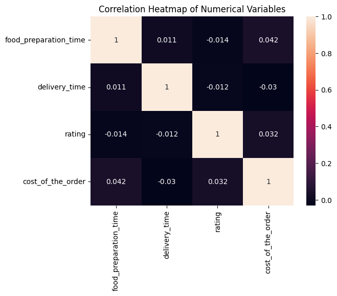

```python
# Creating heatmap for different numerical variables
sns.heatmap(data = order_df[['food_preparation_time', 'delivery_time', 'rating', 'cost_of_the_order', ]].corr(), annot=True)
plt.title("Correlation Heatmap of Numerical Variables")

# Show the plot
plt.show()
```

#### Observation:

1. The correlation values are very low, indicating weak or no correlation between the variables.
2. Food preparation time & cost of the order (0.042) → Very weak positive correlation.
3. Delivery time & cost of the order (-0.03) → Slight negative correlation, meaning higher delivery time does not lead to higher costs.
4. Rating & other variables (~0) → No significant relationship between rating and other factors.

### 5. Relationship between Cost of the order and Cuisine Type

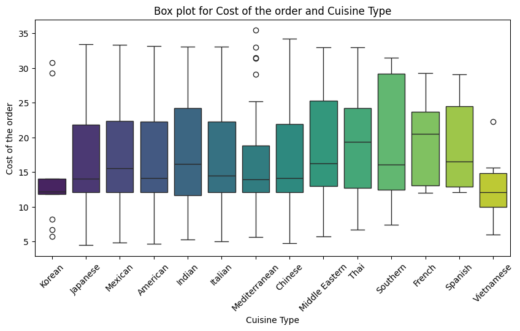

```python
# Relationship between cost of the order and cuisine type
plt.figure(figsize=(10,5))
sns.boxplot(x = "cuisine_type", y = "cost_of_the_order", data = order_df, palette='viridis', hue = "cuisine_type");

# Plot Customization
plt.title('Box plot for Cost of the order and Cuisine Type')
plt.xlabel('Cuisine Type')
plt.ylabel('Cost of the order')
plt.xticks(rotation = 45)

# Show the plot
plt.show()
```

### 6. Relationship between Cost of the order and Day of the week

[figure not shown]

```python
# Creating box plot for cost of the order and Day of the week
plt.figure(figsize=(10,5))
sns.boxplot(x = "day_of_the_week", y = "cost_of_the_order", data = order_df, palette = 'RdPu', hue = "day_of_the_week")


# Plot Customization
plt.title('Box plot for Day of the week and Cuisine Type')
plt.xlabel('Day of the week')
plt.ylabel('Cost of the order')

# Show the plot
plt.show()
```

#### Observations:

1. The median cost of orders is almost the same on weekdays and weekends, suggesting that people spend a consistent amount regardless of the day.
2. The maximum order cost is higher on weekdays, which may indicate that corporate orders, large family order are more common during the workweek.
3. People may spend more on weekdays for convenience but opt for dine-in experiences on weekends.\

### 7. Relationship between Deliverytime and Day of the week

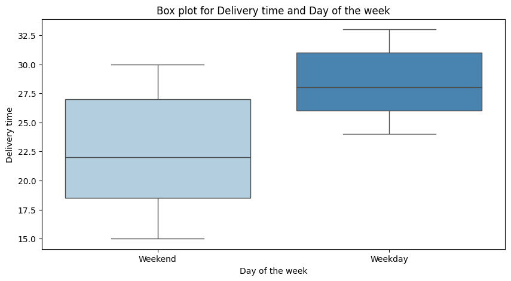

```python
# Creating box plot for delivery time and Day of the week
plt.figure(figsize=(10,5))
sns.boxplot(x = "day_of_the_week", y = "delivery_time", data = order_df, palette = 'Blues', hue = "day_of_the_week")


# Plot Customization
plt.title('Box plot for Delivery time and Day of the week')
plt.xlabel('Day of the week')
plt.ylabel('Delivery time')

# Show the plot
plt.show()
```

#### Observations:

1. Longer delivery times on weekdays: The median and overall range of delivery times are higher on weekdays compared to weekends.
2. Faster deliveries on weekends: The median delivery time is lower on weekends, indicating quicker service.
3. Possible reasons for weekday delays could be fewer available delivery personnel compared to weekends and increased traffic congestion on weekdays.
4. To company needs to fous on increasing driver availability during weekdays to match demand and reduce delivery delays and also to optimize delivery routes using real-time traffic data to minimize delays.

### 7. Relationship between Food Preparation Time and Day of the week

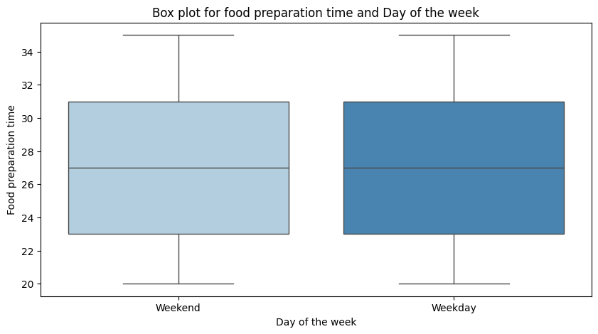

```python
# Creating box plot for food preparation time and Day of the week
plt.figure(figsize=(10,5))
sns.boxplot(x = "day_of_the_week", y = "food_preparation_time", data = order_df, palette = 'Blues', hue = "day_of_the_week")


# Plot Customization
plt.title('Box plot for food preparation time and Day of the week')
plt.xlabel('Day of the week')
plt.ylabel('Food preparation time')

# Show the plot
plt.show()
```

#### Observation:

1. The median food preparation time is almost identical on both weekdays and weekends (around 27 minutes).
2. This suggests that kitchens operate with consistent efficiency regardless of the day.
3. There is no need for major changes in kitchen staffing or operations between weekdays and weekends.

### 7. Relationship between Cuisine Type and Food Preparation Time

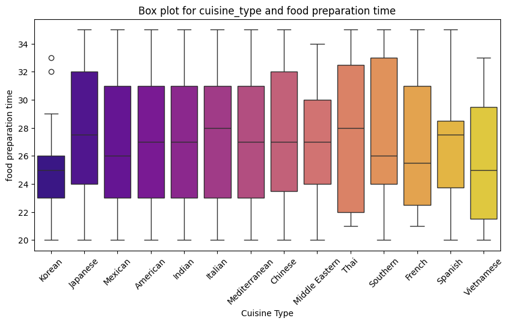

```python
# Relationship between cuisine_type and food preparation time
plt.figure(figsize=(10,5))
sns.boxplot(x = "cuisine_type", y = "food_preparation_time", data = order_df, palette='plasma', hue = "cuisine_type");

# Plot Customization
plt.title('Box plot for cuisine_type and food preparation time')
plt.xlabel('Cuisine Type')
plt.ylabel('food preparation time')
plt.xticks(rotation = 45)

# Show the plot
plt.show()
```

#### Observations:

1. Most cuisines have a similar minimum preparation time of 20 min. This suggests a baseline cooking time across all cuisine types.
2. Korean food has the shortest prep time overall, this could indicate simpler recipes, faster cooking methods, or better kitchen efficiency.
3. Thai food has the longest prep time,this could be due to complex dishes, more ingredients, or longer cooking processes.
4. The interquartile range (IQR) for most cuisines is similar. Most food types fall within a similar time range, but some like Southern and Thai have a slightly wider spread.

### **Question 13:** The company wants to provide a promotional offer in the advertisement of the restaurants. The condition to get the offer is that the restaurants must have a rating count of more than 50 and the average rating should be greater than 4. Find the restaurants fulfilling the criteria to get the promotional offer. [3 marks]

```python
# Counting the number of ratings each restaurants recieved
rating_count = order_df.groupby(['restaurant_name'])['rating'].count().sort_values(ascending=False)
rating_count
```

| restaurant_name | rating |
| --- | --- |
| Shake Shack | 219 |
| The Meatball Shop | 132 |
| Blue Ribbon Sushi | 119 |
| Blue Ribbon Fried Chicken | 96 |
| Parm | 68 |
| ... | ... |
| The MasalaWala | 1 |
| Taro Sushi | 1 |
| Woorijip | 1 |
| Wa Jeal | 1 |
| Wo Hop Restaurant | 1 |

178 rows × 1 columns

**dtype:** int64

```python
# Filter only the restaurant which has rating count more than 50
rating_count_above50 = rating_count[rating_count > 50]
rating_count_above50
```

| restaurant_name | rating |
| --- | --- |
| Shake Shack | 219 |
| The Meatball Shop | 132 |
| Blue Ribbon Sushi | 119 |
| Blue Ribbon Fried Chicken | 96 |
| Parm | 68 |
| RedFarm Broadway | 59 |
| RedFarm Hudson | 55 |

**dtype:** int64

```python
# Create a new dataframe of filtered restaurants with rating count more than 50 so we can compute the average rating for each restaurant
filtered_df_rating_above50 = order_df[order_df['restaurant_name'].isin(rating_count_above50.index)]
filtered_df_rating_above50
```

|  | order_id | customer_id | restaurant_name | cuisine_type | cost_of_the_order | day_of_the_week | rating | food_preparation_time | delivery_time |
| --- | --- | --- | --- | --- | --- | --- | --- | --- | --- |
| 3 | 1477334 | 106968 | Blue Ribbon Fried Chicken | American | 29.200 | Weekend | 3 | 25 | 15 |
| 6 | 1477894 | 157711 | The Meatball Shop | Italian | 6.070 | Weekend | 5 | 28 | 21 |
| 12 | 1476966 | 129969 | Blue Ribbon Fried Chicken | American | 24.300 | Weekend | 5 | 23 | 17 |
| 15 | 1477414 | 66222 | Shake Shack | American | 16.200 | Weekend | 5 | 33 | 25 |
| 18 | 1477138 | 47280 | RedFarm Hudson | Chinese | 14.120 | Weekend | 4 | 25 | 24 |
| ... | ... | ... | ... | ... | ... | ... | ... | ... | ... |
| 1888 | 1477353 | 106324 | The Meatball Shop | Italian | 16.200 | Weekend | 5 | 21 | 26 |
| 1889 | 1478190 | 94152 | RedFarm Broadway | Chinese | 8.680 | Weekday | 3 | 33 | 30 |
| 1891 | 1476981 | 138586 | Shake Shack | American | 5.820 | Weekend | 4 | 22 | 28 |
| 1895 | 1477819 | 35309 | Blue Ribbon Sushi | Japanese | 25.220 | Weekday | 4 | 31 | 24 |
| 1897 | 1478056 | 120353 | Blue Ribbon Sushi | Japanese | 19.450 | Weekend | 4 | 28 | 24 |

748 rows × 9 columns

```python
# Calculating the average rating of the filtered restaurant list
average_rating = filtered_df_rating_above50.groupby('restaurant_name')['rating'].mean()
average_rating
```

| restaurant_name | rating |
| --- | --- |
| Blue Ribbon Fried Chicken | 4.219 |
| Blue Ribbon Sushi | 4.134 |
| Parm | 4.074 |
| RedFarm Broadway | 4.169 |
| RedFarm Hudson | 4.109 |
| Shake Shack | 4.169 |
| The Meatball Shop | 4.689 |

**dtype:** float64

- The output calculates the average rating for each restaurants

```python
# To filter only the eligible restaurants who are having average rating greater than 4
eligibile_restaurants = average_rating[average_rating > 4].sort_values(ascending=False)
eligibile_restaurants
```

| restaurant_name | rating |
| --- | --- |
| The Meatball Shop | 4.689 |
| Blue Ribbon Fried Chicken | 4.219 |
| RedFarm Broadway | 4.169 |
| Shake Shack | 4.169 |
| Blue Ribbon Sushi | 4.134 |
| RedFarm Hudson | 4.109 |
| Parm | 4.074 |

**dtype:** float64

```python
# Check the count of unique restaurants in the dataset
order_df['restaurant_name'].nunique()
```

```
178
```

- There are 178 unique restaurants in the dataset

### **Question 14:** The company charges the restaurant 25% on the orders having cost greater than 20 dollars and 15% on the orders having cost greater than 5 dollars. Find the net revenue generated by the company across all orders. [3 marks]

```python
# Function to calculate the revenue based on the condition given in the question
def calc_revenue(x):
  if x > 20:
    return 0.25 * x
  elif x > 5:
    return 0.15 * x
  else:
    return 0

# Creating a new column that calculates the net revenue by applying the function
order_df['Net revenue'] = order_df['cost_of_the_order'].apply(calc_revenue)
order_df
```

|  | order_id | customer_id | restaurant_name | cuisine_type | cost_of_the_order | day_of_the_week | rating | food_preparation_time | delivery_time | Net revenue |
| --- | --- | --- | --- | --- | --- | --- | --- | --- | --- | --- |
| 0 | 1477147 | 337525 | Hangawi | Korean | 30.750 | Weekend | 4 | 25 | 20 | 7.688 |
| 1 | 1477685 | 358141 | Blue Ribbon Sushi Izakaya | Japanese | 12.080 | Weekend | 5 | 25 | 23 | 1.812 |
| 2 | 1477070 | 66393 | Cafe Habana | Mexican | 12.230 | Weekday | 5 | 23 | 28 | 1.835 |
| 3 | 1477334 | 106968 | Blue Ribbon Fried Chicken | American | 29.200 | Weekend | 3 | 25 | 15 | 7.300 |
| 4 | 1478249 | 76942 | Dirty Bird to Go | American | 11.590 | Weekday | 4 | 25 | 24 | 1.738 |
| ... | ... | ... | ... | ... | ... | ... | ... | ... | ... | ... |
| 1893 | 1476701 | 292602 | Chipotle Mexican Grill $1.99 Delivery | Mexican | 22.310 | Weekend | 5 | 31 | 17 | 5.577 |
| 1894 | 1477421 | 397537 | The Smile | American | 12.180 | Weekend | 5 | 31 | 19 | 1.827 |
| 1895 | 1477819 | 35309 | Blue Ribbon Sushi | Japanese | 25.220 | Weekday | 4 | 31 | 24 | 6.305 |
| 1896 | 1477513 | 64151 | Jack's Wife Freda | Mediterranean | 12.180 | Weekday | 5 | 23 | 31 | 1.827 |
| 1897 | 1478056 | 120353 | Blue Ribbon Sushi | Japanese | 19.450 | Weekend | 4 | 28 | 24 | 2.917 |

1898 rows × 10 columns

```python
total_revenue = order_df['Net revenue'].sum()
print(f'The total revenue generated by the company across all orders is {total_revenue:.2f}$')
```

```
The total revenue generated by the company across all orders is 6166.30$
```

#### Observations:

1. The total revenue generated by the company across all orders is 6166.30$

### **Question 15:** The company wants to analyze the total time required to deliver the food. What percentage of orders take more than 60 minutes to get delivered from the time the order is placed? (The food has to be prepared and then delivered.) [2 marks]

```python
# Create a new column with total time required to deliver the food (food_preparation_time + delivery_time)
order_df['total_time_taken'] = order_df['food_preparation_time'] + order_df['delivery_time']
order_df
```

|  | order_id | customer_id | restaurant_name | cuisine_type | cost_of_the_order | day_of_the_week | rating | food_preparation_time | delivery_time | Net revenue | total_time_taken |
| --- | --- | --- | --- | --- | --- | --- | --- | --- | --- | --- | --- |
| 0 | 1477147 | 337525 | Hangawi | Korean | 30.750 | Weekend | 4 | 25 | 20 | 7.688 | 45 |
| 1 | 1477685 | 358141 | Blue Ribbon Sushi Izakaya | Japanese | 12.080 | Weekend | 5 | 25 | 23 | 1.812 | 48 |
| 2 | 1477070 | 66393 | Cafe Habana | Mexican | 12.230 | Weekday | 5 | 23 | 28 | 1.835 | 51 |
| 3 | 1477334 | 106968 | Blue Ribbon Fried Chicken | American | 29.200 | Weekend | 3 | 25 | 15 | 7.300 | 40 |
| 4 | 1478249 | 76942 | Dirty Bird to Go | American | 11.590 | Weekday | 4 | 25 | 24 | 1.738 | 49 |
| ... | ... | ... | ... | ... | ... | ... | ... | ... | ... | ... | ... |
| 1893 | 1476701 | 292602 | Chipotle Mexican Grill $1.99 Delivery | Mexican | 22.310 | Weekend | 5 | 31 | 17 | 5.577 | 48 |
| 1894 | 1477421 | 397537 | The Smile | American | 12.180 | Weekend | 5 | 31 | 19 | 1.827 | 50 |
| 1895 | 1477819 | 35309 | Blue Ribbon Sushi | Japanese | 25.220 | Weekday | 4 | 31 | 24 | 6.305 | 55 |
| 1896 | 1477513 | 64151 | Jack's Wife Freda | Mediterranean | 12.180 | Weekday | 5 | 23 | 31 | 1.827 | 54 |
| 1897 | 1478056 | 120353 | Blue Ribbon Sushi | Japanese | 19.450 | Weekend | 4 | 28 | 24 | 2.917 | 52 |

1898 rows × 11 columns

- We can see new column named total_time_taken with sum of food_preparation_time and delivery_time

```python
# Number of orders that has total_time_taken greater than 60
num_orders_above_60 = order_df[order_df['total_time_taken'] > 60].shape[0]
num_orders_above_60
```

```
200
```

- 200 orders took time more than 60 minutes to deliver the food to the customer

```python
# total number of orders in the dataset
total_orders
```

```
1898
```

```python
# Percentage of orders that has taken more than 60 minutes
percentage_orders_above_60 = (num_orders_above_60 / total_orders) * 100
print(f'{percentage_orders_above_60:.2f}% of orders took more than 60 minutes to get delivered from the time the order was placed')
```

```
10.54% of orders took more than 60 minutes to get delivered from the time the order was placed
```

#### Observations:

1. 200 orders took time more than 60 minutes to deliver the food to the customer which is **10.54%** of the total orders

### **Question 16:** The company wants to analyze the delivery time of the orders on weekdays and weekends. How does the mean delivery time vary during weekdays and weekends? [2 marks]

```python
# Calculate the mean delivery time by grouping day of the week column
mean_delivery_by_dayoftheweek = order_df.groupby(['day_of_the_week'])['delivery_time'].mean()
mean_delivery_by_dayoftheweek
```

| day_of_the_week | delivery_time |
| --- | --- |
| Weekday | 28.340 |
| Weekend | 22.470 |

**dtype:** float64

#### Observations:

1. The output shows that the average delivery time on weekdays is 28.34 minutes, whereas on weekends, it is 22.47 minutes.
2. This indicates that the mean delivery time is lower on weekends compared to weekdays.

### Conclusion and Recommendations

### **Question 17:** What are your conclusions from the analysis? What recommendations would you like to share to help improve the business? (You can use cuisine type and feedback ratings to drive your business recommendations.) [6 marks]

### **Conclusions**:

I analyzed the foodhub dataset of nearly 1,900 orders. The data covers various aspects such as restaurant names, cuisine types, order costs, customer ratings, food preparation times, and delivery times. Given that both customer satisfaction and operational efficiency are crucial for FoodHub's success, it’s essential to ensure that orders are processed promptly and that popular cuisines are leveraged to drive business. The analysis allowed to uncover key trends that can help optimize operations and marketing strategies.

### **Insights**:

1. **Food Preparation and Delivery Times:**
   - On average, food takes about 27 minutes to prepare and 24 minutes to deliver.
   - Delivery takes longer on weekdays compared to weekends, likely because there are fewer delivery people or more traffic.
2. **Cost of Orders and Customer Behavior:**
   - About 29% of the orders cost more than 20$.
   - And 70.76% of order costs less then 20$, indicating majority of the customers are interested in buying low cost food.
   - On weekends, American cuisine is the most popular, suggesting customers choose comfort food.
3. **Customer Ratings and Order Costs:**
   - There is no strong link between the cost of an order and its rating, meaning price does not mainly drive customer satisfaction.
   - Majority of the restaurants consistently receive higher ratings and no restaurant has got rating below 3 which implies strong positive customer feedback.
4. **Revenue Generation:**
   - Total Order Value ($31,314.82): This is the gross amount of all orders.
   - FoodHub Revenue ($6,166.30): This is the net earnings from orders after taking their commission (revenue calculated as per question 14).
   - FoodHub earns roughly 19.7% of the total order value as revenue.
5. **Popular Cuisines and Restaurants:**
   - **Top 3 Cuisines:** Based on order frequency, the top 3 cuisines are:
     - American
     - Japanese
     - Italian
   - **Top 3 Restaurants:** The analysis identified the top 3 restaurants:
     - Shake Shack
     - The Meatball Shop
     - Blue Ribbon Shushi
   - **Weekend Popularity:**
     - American cuisine is especially popular on weekends, suggesting a strong customer preference for that cuisine.
6. **Weekend vs. Weekday Orders:**
- Total Orders: The dataset contains 1,898 orders.
- Approximately 547 orders were placed on weekdays, and 1351 orders were placed on weekends.
- Even though the order volume is lower on weekdays, the longer delivery times during these periods may need addressing.